# Activity: Street or Road?

Abdulaziz Bokijonov

## Load in the data

```r
#load libraries
library(tidyverse)
library(dcData)
#load in the data here
# we will only be using the "street-addresses.csv" file from the text
download.file(url="https://mdbeckman.github.io/dcSupplement/data/street-addresses.csv",
              destfile = "street-addresses.csv")
DataTable <- read.csv("street-addresses.csv")
```

## Recreate Solved Example using `sample(50)`

```r
Sample <-
  DataTable %>%
  sample_n(size = 50)
Sample
```

| address |
| --- |
| 3500 EDWARDS MILL RD |
| PO BOX 40003 |
| PO BOX 12411 |
| PO BOX 1867 |
| 3810 APT 105 |
| NCSU BOX 03263 |
| P O BOX 1208 |
| P O BOX 46508 |
| NCSU BOX 21565 |
| BOX 01344518 |

[output cut: 40 more lines]

## Recreate Soved Example using the entire `Address` data set

```r
Matches <-
  DataTable %>%
  filter(grepl(pattern = "PO", address))
Matches
```

| address |
| --- |
| PO BOX 58592 |
| PO BOX 37218 |
| PO BOX 37218 |
| PO BOX 1953 |
| PO BOX 132 |
| PO BOX 360 |
| PO BOX 118 |
| PO BOX 1462 |
| PO BOX 603 |
| PO BOX 1348 |

[output cut: 990 more lines]

#### Additional Question: How many addresses are a PO BOX (including NCSU BOX)?

```r
Matches <-
  DataTable %>%
  filter(grepl(pattern = "PO", address))
Matches2 <-
  DataTable %>%
  filter(grepl(pattern = "NCSU", address))

nrow(Matches)
```

```
[1] 8347
```

```r
nrow(Matches2)
```

```
[1] 2380
```

There are 8347 PO and 2380 NCSU BOX addresses. In total 10727 matches

## Back to the Streets: Your Turn

#### Part 1: Explain (in english) each line of the following code chunk

```r
pattern <- "(ST|RD|ROAD)"
LeftOvers <-
  DataTable %>%
  filter( !grepl(pattern, address),
          !grepl("\\sAPT|UNIT\\s[\\d]+$", address),
          !grepl(" BOX ", address)
          )
```

1. Assigns string “(ST|RD|ROAD)” to pattern variable
2. New object LeftOvers and assigns following lines
3. DataTable followed by %>% which means next lines are related to DataTable variable
4. Filter function with !grepl function inside that excludes rows that have ST RD or ROAD in address column
5. grepl function has the pattern matches strings in address column that end with either ” APT” or ” UNIT” followed by one or more digits, and ! excludes those matched rows.
6. Excludes address column entries that contain ” BOX”
7. Closes filter function

#### Part 2: Implement your method on the entire `Addresses` data set. Explain how your code works line by line.

```r
AddressEndings <- data.frame(ending = sub('.*\\ ', '', LeftOvers$address))
AddressEndings %>%
  group_by(ending) %>%
  summarise(count = n()) %>%
  arrange(desc(count))
```

| ending | count |
| --- | --- |
| DR | 518 |
| DRIVE | 214 |
| CT | 187 |
| LN | 132 |
| AVE | 127 |
| LANE | 118 |
| WAY | 84 |
| COURT | 71 |
| PL | 55 |
| CIR | 51 |

[output cut: 382 more lines]

```r
NA
```

1. Created new object AddressEnding and assigned it a data frame that uses sub() function on LeftOvers object and gets the last string after the last white space in the address column
2. %>% on AddresEnding which makes the next lines make operations with AddresEnding
3. summarise function that count the groups of endings of the streets
4. sort in descending order

#### Additional Question 1: Present your result from part 2 by providing a table in descending order of popularity for the street name endings you found

```r
popular <- AddressEndings %>%
  group_by(ending) %>%
  summarise(count = n()) %>%
  arrange(desc(count))
popular
```

| ending | count |
| --- | --- |
| DR | 518 |
| DRIVE | 214 |
| CT | 187 |
| LN | 132 |
| AVE | 127 |
| LANE | 118 |
| WAY | 84 |
| COURT | 71 |
| PL | 55 |
| CIR | 51 |

[output cut: 382 more lines]

#### Additional Question 2: Present your result by using ggplot to a bar chart in descending order of popularity for the street name endings you found previously.

Note: make sure your order street names according to popularity, not alphabetically.

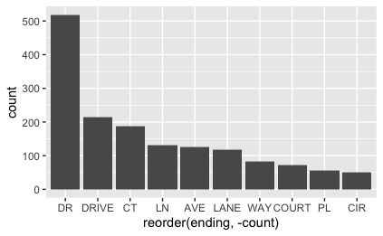

```r
head(popular,10) %>%
  ggplot(aes(x=reorder(ending, -count),y=count)) +
  geom_bar(stat='identity',position='stack', width=.9)
```

#### Additional Question 3: Comment on any patterns you see

I used only top 10 entries to keep the plot clean and the most popular one is DR, then DRIVE. “Drive” or its abriviation are the most popular endings.